# Chapter 7 Lab 8 - Decision Tree (DT)

# Goal

In this lab, we, again, will try to predict players’ skill level, i.e., column `SkillLevel`, which takes integer value between 0 and 3, with 0 being novice level and 3 expert. We will use a `Decision Tree` algorithm, called *CART*, implemented in the package `rpart` for this purpose. Again, this algorithm implementation is wrapped by the `caret` package, which we will used for data preprocessing as well.

*CART* stands for **C**lassification **a**nd **R**egression **T**rees, which is the implementation for `Decision Tree` algorithms that can be used for both classification and regression tasks. For variable selection at internal nodes, `CART` uses `Gini` score, instead of `Information Gain`, to determine the homogenity of the resultant split.

## Brief refresher

`Decision Tree (DT)` is a powerful classification method, which can also be used for regression tasks. It is able to approximate non-linear patterns in the data, by consecutively splitting the data according to the values of independent variables.

## Preparation

```r
# install the rpart package if you don't already have it
options(repos = c(CRAN = "http://cran.rstudio.com"))
install.packages("caret", dependencies = TRUE)
install.packages("rpart", dependencies = TRUE)
library("rpart")
library("caret")
# (optional) set working directory

# read the CSV file
DotaData <- read.csv("DoTalicious_cleaned1000players.csv", fileEncoding="UTF-8-BOM")
summary(DotaData)
```

```
##     PlayerID       GamesPlayed         GamesWon         GamesLeft
##  Min.   :   0.0   Min.   :   0.00   Min.   :   0.00   Min.   : 0.000
##  1st Qu.: 242.8   1st Qu.:   3.00   1st Qu.:   1.00   1st Qu.: 0.000
##  Median : 499.5   Median :  15.00   Median :   7.00   Median : 0.000
##  Mean   : 497.7   Mean   :  92.24   Mean   :  50.31   Mean   : 1.649
##  3rd Qu.: 750.2   3rd Qu.:  90.00   3rd Qu.:  47.25   3rd Qu.: 2.000
##  Max.   :1000.0   Max.   :3156.00   Max.   :1764.00   Max.   :40.000
##     Ditches            Points        SkillLevel            Kills
##  Min.   : 0.0000   Min.   : 626.8   Length:868         Min.   :    0.0
##  1st Qu.: 0.0000   1st Qu.: 962.1   Class :character   1st Qu.:   11.0
##  Median : 0.0000   Median : 996.7   Mode  :character   Median :   74.0
##  Mean   : 0.7108   Mean   :1014.8                      Mean   :  608.0
##  3rd Qu.: 1.0000   3rd Qu.:1046.7                      3rd Qu.:  512.8
##  Max.   :18.0000   Max.   :2010.2                      Max.   :23742.0
##   KillsPerMin         Deaths           Assists         CreepsKilled
##  Min.   :0.0000   Min.   :    0.0   Min.   :    0.0   Min.   :     0.0
##  1st Qu.:0.0900   1st Qu.:   17.0   1st Qu.:   18.0   1st Qu.:   159.5
##  Median :0.1300   Median :   92.5   Median :  124.0   Median :   979.0
##  Mean   :0.1316   Mean   :  544.5   Mean   :  950.7   Mean   :  7628.0
##  3rd Qu.:0.1700   3rd Qu.:  554.0   3rd Qu.:  863.5   3rd Qu.:  6723.0
##  Max.   :0.4200   Max.   :16988.0   Max.   :34390.0   Max.   :372360.0
##   CreepsDenied     NeutralsKilled    TowersDestroyed   RaxsDestroyed
##  Min.   :    0.0   Min.   :    0.0   Min.   :   0.00   Min.   :   0.00
##  1st Qu.:   12.0   1st Qu.:   16.0   1st Qu.:   1.00   1st Qu.:   0.00
##  Median :   76.0   Median :  145.5   Median :   7.00   Median :   3.00
##  Mean   :  676.9   Mean   : 1258.3   Mean   :  70.71   Mean   :  29.71
##  3rd Qu.:  540.8   3rd Qu.: 1126.8   3rd Qu.:  61.50   3rd Qu.:  26.00
##  Max.   :43910.0   Max.   :42900.0   Max.   :2601.00   Max.   :1141.00
##   TotalTime
##  Length:868
##  Class :character
##  Mode  :character
##
##
##
```

Clean up and set the correct data type.

```r
# convert TotalTime
DotaData$TotalTime <- as.numeric(DotaData$TotalTime)
# exclude the row with SillLevel = SkillLevelNull
DotaData$SkillLevel <- as.factor(DotaData$SkillLevel)
DotaData <- DotaData[!(DotaData$SkillLevel == " SkillLevelNull"),]

# use factor in place of as.factor to remove " SkillLevelNull" from the list of factors
DotaData$SkillLevel <- factor(DotaData$SkillLevel)

# exclude PlayerID
DotaData <- DotaData[-1]

DotaData = na.omit(DotaData)

summary(DotaData)
```

```
##   GamesPlayed         GamesWon         GamesLeft         Ditches
##  Min.   :   1.00   Min.   :   0.00   Min.   : 0.000   Min.   : 0.0000
##  1st Qu.:   3.00   1st Qu.:   1.00   1st Qu.: 0.000   1st Qu.: 0.0000
##  Median :  15.00   Median :   7.00   Median : 0.000   Median : 0.0000
##  Mean   :  92.35   Mean   :  50.39   Mean   : 1.649   Mean   : 0.7125
##  3rd Qu.:  89.75   3rd Qu.:  47.75   3rd Qu.: 2.000   3rd Qu.: 1.0000
##  Max.   :3156.00   Max.   :1764.00   Max.   :40.000   Max.   :18.0000
##      Points       SkillLevel     Kills          KillsPerMin
##  Min.   : 626.8   0:446      Min.   :    0.0   Min.   :0.0000
##  1st Qu.: 962.3   1:391      1st Qu.:   11.0   1st Qu.:0.0900
##  Median : 996.7   2: 17      Median :   74.0   Median :0.1300
##  Mean   :1015.0   3: 12      Mean   :  608.8   Mean   :0.1318
##  3rd Qu.:1047.2              3rd Qu.:  516.2   3rd Qu.:0.1700
##  Max.   :2010.2              Max.   :23742.0   Max.   :0.4200
##      Deaths            Assists         CreepsKilled       CreepsDenied
##  Min.   :    0.00   Min.   :    0.0   Min.   :     9.0   Min.   :    0.0
##  1st Qu.:   17.25   1st Qu.:   18.0   1st Qu.:   160.2   1st Qu.:   12.0
##  Median :   92.50   Median :  124.0   Median :   979.0   Median :   76.0
##  Mean   :  545.09   Mean   :  952.0   Mean   :  7637.0   Mean   :  678.0
##  3rd Qu.:  554.00   3rd Qu.:  866.5   3rd Qu.:  6690.8   3rd Qu.:  542.2
##  Max.   :16988.00   Max.   :34390.0   Max.   :372360.0   Max.   :43910.0
##  NeutralsKilled    TowersDestroyed   RaxsDestroyed       TotalTime
##  Min.   :    0.0   Min.   :   0.00   Min.   :   0.00   Min.   :   1349
##  1st Qu.:   16.0   1st Qu.:   1.00   1st Qu.:   0.00   1st Qu.:   6255
##  Median :  145.5   Median :   7.00   Median :   3.00   Median :  35070
##  Mean   : 1258.7   Mean   :  70.79   Mean   :  29.74   Mean   : 228343
##  3rd Qu.: 1118.5   3rd Qu.:  61.00   3rd Qu.:  26.00   3rd Qu.: 220815
##  Max.   :42900.0   Max.   :2601.00   Max.   :1141.00   Max.   :4294920
```

Check if there is any missing value (NA here means Not Available). If it returns *False*, we’re good to go. As we did in the other labs, if there are any NAs, you can remove the NA row by using the `omit` function.

```r
anyNA(DotaData)
```

```
## [1] FALSE
```

# Step 2: Set up training and test set

```r
# setting the random seed
set.seed(101)
#Spliting data as training and test set. Using createDataPartition() function from caret
indxTrain <- createDataPartition(y = DotaData$SkillLevel,p = 0.75,list = FALSE)
training <- DotaData[indxTrain,]
testing <- DotaData[-indxTrain,]
summary(training)
```

```
##   GamesPlayed         GamesWon         GamesLeft         Ditches
##  Min.   :   1.00   Min.   :   0.00   Min.   : 0.000   Min.   : 0.0000
##  1st Qu.:   3.00   1st Qu.:   1.00   1st Qu.: 0.000   1st Qu.: 0.0000
##  Median :  16.00   Median :   7.00   Median : 0.000   Median : 0.0000
##  Mean   :  92.07   Mean   :  50.69   Mean   : 1.639   Mean   : 0.6882
##  3rd Qu.:  90.00   3rd Qu.:  47.50   3rd Qu.: 2.000   3rd Qu.: 1.0000
##  Max.   :3156.00   Max.   :1764.00   Max.   :40.000   Max.   :15.0000
##      Points       SkillLevel     Kills          KillsPerMin
##  Min.   : 626.8   0:335      Min.   :    0.0   Min.   :0.0000
##  1st Qu.: 963.9   1:294      1st Qu.:   11.0   1st Qu.:0.0900
##  Median :1000.0   2: 13      Median :   74.0   Median :0.1300
##  Mean   :1016.0   3:  9      Mean   :  616.5   Mean   :0.1332
##  3rd Qu.:1044.7              3rd Qu.:  514.5   3rd Qu.:0.1700
##  Max.   :2010.2              Max.   :23742.0   Max.   :0.4200
##      Deaths           Assists         CreepsKilled     CreepsDenied
##  Min.   :    0.0   Min.   :    0.0   Min.   :     9   Min.   :    0.0
##  1st Qu.:   16.0   1st Qu.:   18.0   1st Qu.:   156   1st Qu.:   12.0
##  Median :  100.0   Median :  130.0   Median :   991   Median :   79.0
##  Mean   :  539.6   Mean   :  959.8   Mean   :  7558   Mean   :  674.8
##  3rd Qu.:  548.5   3rd Qu.:  882.0   3rd Qu.:  6528   3rd Qu.:  541.5
##  Max.   :16988.0   Max.   :34390.0   Max.   :372360   Max.   :43910.0
##  NeutralsKilled  TowersDestroyed   RaxsDestroyed       TotalTime
##  Min.   :    0   Min.   :   0.00   Min.   :   0.00   Min.   :   1349
##  1st Qu.:   15   1st Qu.:   1.00   1st Qu.:   0.00   1st Qu.:   5970
##  Median :  156   Median :   7.00   Median :   3.00   Median :  36540
##  Mean   : 1264   Mean   :  70.42   Mean   :  29.71   Mean   : 225830
##  3rd Qu.: 1073   3rd Qu.:  60.00   3rd Qu.:  25.00   3rd Qu.: 227100
##  Max.   :42900   Max.   :2601.00   Max.   :1141.00   Max.   :4294920
```

```r
summary(testing)
```

```
##   GamesPlayed         GamesWon        GamesLeft         Ditches
##  Min.   :   1.00   Min.   :  0.00   Min.   : 0.000   Min.   : 0.000
##  1st Qu.:   3.00   1st Qu.:  1.00   1st Qu.: 0.000   1st Qu.: 0.000
##  Median :  13.00   Median :  6.00   Median : 0.000   Median : 0.000
##  Mean   :  93.19   Mean   : 49.46   Mean   : 1.679   Mean   : 0.786
##  3rd Qu.:  85.00   3rd Qu.: 49.00   3rd Qu.: 2.000   3rd Qu.: 1.000
##  Max.   :1362.00   Max.   :816.00   Max.   :18.000   Max.   :18.000
##      Points       SkillLevel     Kills          KillsPerMin
##  Min.   : 691.3   0:111      Min.   :    0.0   Min.   :0.0000
##  1st Qu.: 954.4   1: 97      1st Qu.:   12.5   1st Qu.:0.0800
##  Median : 994.3   2:  4      Median :   69.0   Median :0.1200
##  Mean   :1011.7   3:  3      Mean   :  585.6   Mean   :0.1276
##  3rd Qu.:1054.5              3rd Qu.:  529.5   3rd Qu.:0.1700
##  Max.   :1592.6              Max.   :11457.0   Max.   :0.3700
##      Deaths          Assists         CreepsKilled     CreepsDenied
##  Min.   :   2.0   Min.   :    0.0   Min.   :    10   Min.   :    0.0
##  1st Qu.:  21.5   1st Qu.:   18.5   1st Qu.:   183   1st Qu.:   12.0
##  Median :  78.0   Median :  100.0   Median :   914   Median :   69.0
##  Mean   : 561.6   Mean   :  928.7   Mean   :  7875   Mean   :  687.9
##  3rd Qu.: 569.0   3rd Qu.:  783.0   3rd Qu.:  6884   3rd Qu.:  538.0
##  Max.   :9322.0   Max.   :14645.0   Max.   :142043   Max.   :13030.0
##  NeutralsKilled  TowersDestroyed  RaxsDestroyed      TotalTime
##  Min.   :    0   Min.   :   0.0   Min.   :  0.00   Min.   :   1354
##  1st Qu.:   19   1st Qu.:   1.0   1st Qu.:  0.00   1st Qu.:   7080
##  Median :  116   Median :   7.0   Median :  3.00   Median :  29820
##  Mean   : 1242   Mean   :  71.9   Mean   : 29.85   Mean   : 235952
##  3rd Qu.: 1218   3rd Qu.:  64.0   3rd Qu.: 31.00   3rd Qu.: 215430
##  Max.   :21770   Max.   :1501.0   Max.   :662.00   Max.   :3557400
```

## Data Standardization

No scaling of the data is necessary.

# Step 3: Build the decision tree

The `DT` algorithm implemented in the `rpart` package will be used to build our model. The *train* and *predict* function remains the same as in the case with other `caret` algorithms we used before, with the only difference is in setting the method.

## Train

Set the method in the `train` function to “rpart” to build a decision tree.

```r
set.seed(101)
ctrl <- trainControl(method="repeatedcv", number = 10, repeats = 3)
dt_model <- train(SkillLevel ~ ., data = training, method = "rpart", trControl = ctrl, tuneLength = 20, model=TRUE)
```

Let’s take a look at the model

```r
#looking at the model
dt_model
```

```
## CART
##
## 651 samples
##  15 predictor
##   4 classes: '0', '1', '2', '3'
##
## No pre-processing
## Resampling: Cross-Validated (10 fold, repeated 3 times)
## Summary of sample sizes: 586, 586, 587, 586, 586, 586, ...
## Resampling results across tuning parameters:
##
##   cp          Accuracy   Kappa
##   0.00000000  0.8782299  0.7687567
##   0.04230513  0.8956437  0.7989736
##   0.08461026  0.8956437  0.7989736
##   0.12691539  0.8956437  0.7989736
##   0.16922052  0.8956437  0.7989736
##   0.21152565  0.8956437  0.7989736
##   0.25383078  0.8956437  0.7989736
##   0.29613591  0.8956437  0.7989736
##   0.33844104  0.8956437  0.7989736
##   0.38074617  0.8956437  0.7989736
##   0.42305130  0.8956437  0.7989736
##   0.46535643  0.8956437  0.7989736
##   0.50766156  0.8956437  0.7989736
##   0.54996669  0.8956437  0.7989736
##   0.59227182  0.8956437  0.7989736
##   0.63457695  0.8956437  0.7989736
##   0.67688208  0.8956437  0.7989736
##   0.71918721  0.8956437  0.7989736
##   0.76149234  0.8956437  0.7989736
##   0.80379747  0.7060057  0.4039708
##
## Accuracy was used to select the optimal model using the largest value.
## The final value used for the model was cp = 0.7614923.
```

Plotting the cross validation result of tuning the `cp` parameter. `cp` is the stopping parameter and it specifically defines the minimum improvement in the model needed at each node. As you can see from the results the model suggests a specific `cp` that gives us the best accuracy with the training data. Plotting `cp` will make it clearer

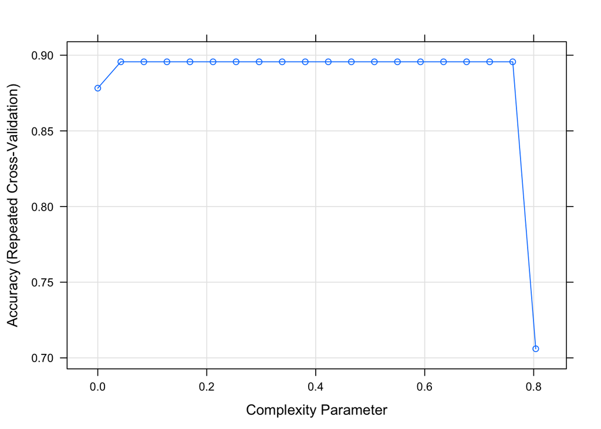

```r
plot(dt_model)
```

## Predict

```r
predicted <- predict(dt_model, newdata = testing)
confusionMatrix(predicted, testing$SkillLevel )
```

```
## Confusion Matrix and Statistics
##
##           Reference
## Prediction  0  1  2  3
##          0 98  3  0  0
##          1 13 94  4  3
##          2  0  0  0  0
##          3  0  0  0  0
##
## Overall Statistics
##
##                Accuracy : 0.893
##                  95% CI : (0.8438, 0.931)
##     No Information Rate : 0.5163
##     P-Value [Acc > NIR] : < 2.2e-16
##
##                   Kappa : 0.7936
##
##  Mcnemar's Test P-Value : NA
##
## Statistics by Class:
##
##                      Class: 0 Class: 1 Class: 2 Class: 3
## Sensitivity            0.8829   0.9691   0.0000  0.00000
## Specificity            0.9712   0.8305   1.0000  1.00000
## Pos Pred Value         0.9703   0.8246      NaN      NaN
## Neg Pred Value         0.8860   0.9703   0.9814  0.98605
## Prevalence             0.5163   0.4512   0.0186  0.01395
## Detection Rate         0.4558   0.4372   0.0000  0.00000
## Detection Prevalence   0.4698   0.5302   0.0000  0.00000
## Balanced Accuracy      0.9270   0.8998   0.5000  0.50000
```

Examining the accuracy and confusion matrix, we can see that our decision tree model performs even better than SVM with Radial basis function kernel used in the previous lab, which demonstrates the power of tree-based approaches.

At this point, it seems clear to us that the amount of data representing Class 2 and 3 in our training data is insufficient to adequately characterize data belonging to these two classes. All models we have tried so far cannot seem to detect correctly these rare classes.

# Step 4: Visualization

Another reason that makes DT popular is the fact that DT is very interpretable. We will demonstrate this point by showing how to visualize this tree and extract insights out of it.

First, install the plotting package for `rpart`.

```r
# do not run these steps if you already have the packages installed.
install.packages("rpart.plot", dependencies = TRUE)
```

Second, load packages

```r
library(rpart.plot)
```

Lastly, visualize the tree, captured by the element `finalModel` in the output object returned by the `train` function.

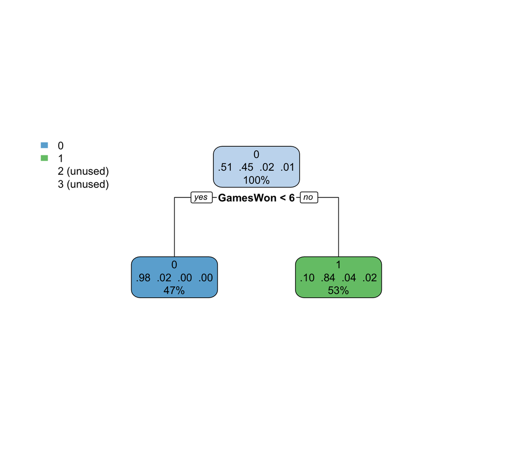

```r
rpart.plot(dt_model$finalModel)
```

This is a sign that we are having an independent variable that is too strong for our prediction task. So, let’s retrain the model without the `GamesWon` variable.

```r
set.seed(101)
ctrl <- trainControl(method="repeatedcv", number = 10, repeats = 3)
dt_model <- train(SkillLevel ~ . - GamesWon, data = training, method = "rpart", trControl = ctrl, tuneLength = 20, model=TRUE)

predicted <- predict(dt_model, newdata = testing)
confusionMatrix(predicted, testing$SkillLevel )
```

```
## Confusion Matrix and Statistics
##
##           Reference
## Prediction   0   1   2   3
##          0 100  12   0   0
##          1  11  85   4   3
##          2   0   0   0   0
##          3   0   0   0   0
##
## Overall Statistics
##
##                Accuracy : 0.8605
##                  95% CI : (0.8068, 0.9038)
##     No Information Rate : 0.5163
##     P-Value [Acc > NIR] : < 2.2e-16
##
##                   Kappa : 0.729
##
##  Mcnemar's Test P-Value : NA
##
## Statistics by Class:
##
##                      Class: 0 Class: 1 Class: 2 Class: 3
## Sensitivity            0.9009   0.8763   0.0000  0.00000
## Specificity            0.8846   0.8475   1.0000  1.00000
## Pos Pred Value         0.8929   0.8252      NaN      NaN
## Neg Pred Value         0.8932   0.8929   0.9814  0.98605
## Prevalence             0.5163   0.4512   0.0186  0.01395
## Detection Rate         0.4651   0.3953   0.0000  0.00000
## Detection Prevalence   0.5209   0.4791   0.0000  0.00000
## Balanced Accuracy      0.8928   0.8619   0.5000  0.50000
```

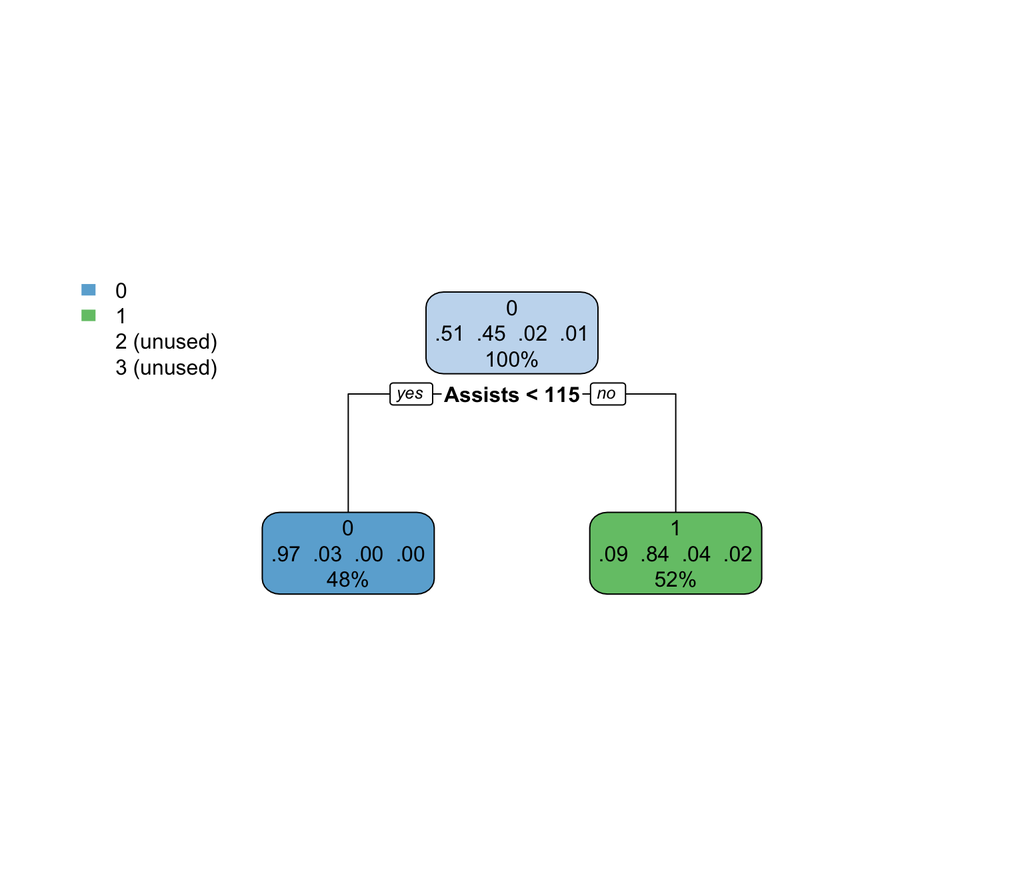

```r
rpart.plot(dt_model$finalModel)
```

Let’s try again, this time excluding both GamesWon and Kills.

```r
set.seed(101)
ctrl <- trainControl(method="repeatedcv", number = 10, repeats = 3)
dt_model <- train(SkillLevel ~ . - GamesWon - Kills, data = training, method = "rpart", trControl = ctrl, tuneLength = 20, model=TRUE)

predicted <- predict(dt_model, newdata = testing)
confusionMatrix(predicted, testing$SkillLevel )
```

```
## Confusion Matrix and Statistics
##
##           Reference
## Prediction   0   1   2   3
##          0 100  12   0   0
##          1  11  85   4   3
##          2   0   0   0   0
##          3   0   0   0   0
##
## Overall Statistics
##
##                Accuracy : 0.8605
##                  95% CI : (0.8068, 0.9038)
##     No Information Rate : 0.5163
##     P-Value [Acc > NIR] : < 2.2e-16
##
##                   Kappa : 0.729
##
##  Mcnemar's Test P-Value : NA
##
## Statistics by Class:
##
##                      Class: 0 Class: 1 Class: 2 Class: 3
## Sensitivity            0.9009   0.8763   0.0000  0.00000
## Specificity            0.8846   0.8475   1.0000  1.00000
## Pos Pred Value         0.8929   0.8252      NaN      NaN
## Neg Pred Value         0.8932   0.8929   0.9814  0.98605
## Prevalence             0.5163   0.4512   0.0186  0.01395
## Detection Rate         0.4651   0.3953   0.0000  0.00000
## Detection Prevalence   0.5209   0.4791   0.0000  0.00000
## Balanced Accuracy      0.8928   0.8619   0.5000  0.50000
```

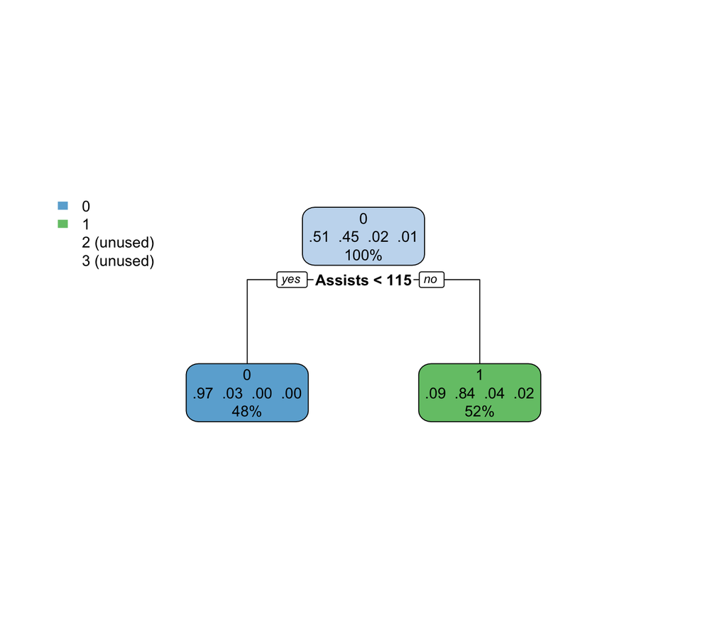

```r
rpart.plot(dt_model$finalModel)
```

It turns out that `Assists` can also be very predictive of the players’ `SkillLevel`.

If this still does not satisfy your curiosity about what affects a player’s `SkillLevel`, you can continue by trying other combinations of independent variables.

# Conclusion